# Biostat 203B Homework 4

Due Mar 12 @ 11:59PM

Benson Wu

Load database libraries and the tidyverse frontend:

```r
library(tidyverse)
library(lubridate)
library(miceRanger)
library(stringr)
library(mice)
library(ddpcr)
library(data.table)
library(caret)
library(healthcareai)
library(glmnet)
library(randomForest)
```

Change directory depending on environment

```r
os <- sessionInfo()$running

#Generate path for mimic data
if (str_detect(os, "Linux")) {
  working_path <- "/home/buwenson/biostat-203b-2021-winter"
} else if (str_detect(os, "macOS")) {
  working_path <-
    "/Users/bensonwu/Documents/UCLA/2020-2021/Winter 2021/BIOSTAT_203B/biostat-203b-2021-winter"
} else {
  working_path <-
    "C:/Users/benson.wu/Documents/biostat-203b-2021-winter-develop/"
}
```

## Q1. Missing data

Through the Shiny app developed in HW3, we observe abundant missing values in the MIMIC-IV ICU cohort we created. In this question, we use multiple imputation to obtain a data set without missing values.

### Part 0

0. Read following tutorials on the R package miceRanger for imputation: https://github.com/farrellday/miceRanger, https://cran.r-project.org/web/packages/miceRanger/vignettes/miceAlgorithm.html.

   A more thorough book treatment of the practical imputation strategies is the book [*Flexible Imputation of Missing Data*](https://stefvanbuuren.name/fimd/) by Stef van Buuren.

### Part 1

1. Explain the jargon MCAR, MAR, and MNAR.

**Q1.1 Solution**

**MCAR** stands for missing completely at random. This means that the probability of being missing is the same for all cases.

**MAR** stands for missing at random. This means that the probability of being missing is the same only within groups defined by the observed data.

**MNAR** stands for missing not at random. This means that the probability of being missing varies for reasons that are unknown to us.

### Part 2

2. Explain in a couple of sentences how the Multiple Imputation by Chained Equations (MICE) work.

**Q1.2 Solution** [Reference for explanation](https://www.ncbi.nlm.nih.gov/pmc/articles/PMC3074241/)

Step 1: A simple imputation, such as imputing the mean, is performed for every missing value in the dataset. These imputations in this missing values act as “place holders.”

Step 2: Start with the variable with the fewest number of missing values. The “place holder” mean imputations for one variable (“var”) are set back to missing.

Step 3: “var” is the dependent variable in a regression model and all the other variables are independent variables in the regression model.

Step 4: The missing values for “var” are then replaced with predictions (imputations) from the regression model. When “var” is subsequently used as an independent variable in the regression models for other variables, both the observed and these imputed values will be used.

Step 5: Moving on to the next variable with the next fewest missing values, steps 2–4 are then repeated for each variable that has missing data. The cycling through each of the variables constitutes one iteration. At the end of one iteration all of the missing values have been replaced with predictions from regressions that reflect the relationships observed in the data.

Step 6: Steps 2 through 4 are repeated for a number of iterations, with the imputations being updated at each iteration. The idea is that by the end of the iterations the distribution of the parameters governing the imputations (e.g., the coefficients in the regression models) should have converged in the sense of becoming stable.

### Part 3

3. Perform a data quality check of the ICU stays data. Discard variables with substantial missingness, say >5000 `NA`s. Replace apparent data entry errors by `NA`s.

**Q1.3 Solution**

We are interested in gender, age, marital status, ethnicity, first lab measurements during ICU stay, and first vital measurements during ICU stay.

First, let’s drop all variables that we will not use

```r
#Read in data set
icu_cohort <- readRDS(str_c(working_path, "/hw3/mimiciv_shiny/icu_cohort.rds"))

keeps<-c("subject_id", "gender", "age_at_adm", "marital_status", "ethnicity",
         "bicarbonate", "calcium", "chloride", "creatinine", "glucose",
         "magnesium", "potassium", "sodium", "hematocrit", "wbc", "lactate",
         "heart_rate", "non_invasive_blood_pressure_systolic",
         "non_invasive_blood_pressure_mean", "respiratory_rate",
         "temperature_fahrenheit", "arterial_blood_pressure_systolic",
         "arterial_blood_pressure_mean", "died_within_30_days")
icu_cohort_filtered <- icu_cohort[, keeps, drop=FALSE]
```

Next, let’s recode erroneous values to `NA` and clean up data. I have decided to make the following changes:

```r
#Marital status
icu_cohort_filtered$marital_status[icu_cohort_filtered$marital_status == ""] <-
  NA
icu_cohort_filtered$marital_status <- factor(icu_cohort_filtered$marital_status)

#Ethnicity: "UNKNOWN" and "UNABLE TO OBTAIN" were recoded to NA
icu_cohort_filtered$ethnicity[icu_cohort_filtered$ethnicity == "UNKNOWN"] <- NA
icu_cohort_filtered$ethnicity[
  icu_cohort_filtered$ethnicity == "UNABLE TO OBTAIN"] <- NA
icu_cohort_filtered$ethnicity <- factor(icu_cohort_filtered$ethnicity)

#Recode gender to make the values numerical
icu_cohort_filtered$gender <-
  recode(icu_cohort_filtered$gender, `F` = 0, `M` = 1)
icu_cohort_filtered$gender <- factor(icu_cohort_filtered$gender)

#Factorize death within 30 days
icu_cohort_filtered$died_within_30_days <- factor(
  icu_cohort_filtered$died_within_30_days)

#Heart rate
tail(sort(icu_cohort_filtered$heart_rate),5)
```

```
## [1] 201 202 217 247 941
```

```r
icu_cohort_filtered$heart_rate[icu_cohort_filtered$heart_rate == 941] <- NA

#Non-invasive systolic blood pressure
tail(sort(icu_cohort_filtered$non_invasive_blood_pressure_systolic),5)
```

```
## [1]   254   258   259   259 12262
```

```r
icu_cohort_filtered$non_invasive_blood_pressure_systolic[
  icu_cohort_filtered$non_invasive_blood_pressure_systolic == 12262] <- NA

#Non-invasive mean blood pressure
tail(sort(icu_cohort_filtered$non_invasive_blood_pressure_mean),10)
```

```
##  [1]    196    197    197    209    215    220    936   6116 120130 140119
```

```r
max<-c(936, 6116, 120130, 140119)
icu_cohort_filtered$non_invasive_blood_pressure_mean[
  icu_cohort_filtered$non_invasive_blood_pressure_mean %in% max] <- NA

#Respiratory rate
tail(sort(icu_cohort_filtered$respiratory_rate),5) #No extreme outliers
```

```
## [1] 115 148 152 160 180
```

```r
#Temperature
head(sort(icu_cohort_filtered$temperature_fahrenheit),150)
```

```
##   [1]  0.0  0.0  0.0  0.0  0.0  0.0  0.0  0.0  0.0  0.0  0.0  0.0  0.0  0.0  0.0
##  [16]  0.0  0.0  0.0  7.4  9.6 30.9 31.7 31.8 32.7 32.9 33.2 33.4 33.6 33.7 33.8
##  [31] 33.8 34.0 34.1 34.1 34.2 34.2 34.3 34.5 34.6 34.7 34.8 35.0 35.0 35.1 35.3
##  [46] 35.4 35.4 35.4 35.5 35.6 35.6 35.7 35.7 35.8 36.1 36.1 36.1 36.2 36.2 36.2
##  [61] 36.2 36.2 36.3 36.4 36.4 36.4 36.5 36.5 36.6 36.6 36.7 36.7 36.7 36.8 36.9
##  [76] 36.9 36.9 36.9 37.0 37.0 37.0 37.0 37.0 37.0 37.1 37.2 37.2 37.2 37.4 37.5
##  [91] 37.5 37.5 37.6 38.2 39.0 39.8 59.7 80.0 80.0 80.0 80.0 80.0 80.0 80.0 81.2
## [106] 81.8 84.3 85.0 85.5 85.6 85.8 86.4 86.5 86.5 86.6 86.6 87.0 87.5 87.7 88.0
## [121] 88.0 88.8 89.0 89.2 89.4 89.9 90.0 90.0 90.0 90.0 90.0 90.0 90.0 90.4 90.4
## [136] 90.7 90.7 90.8 90.9 91.0 91.0 91.0 91.0 91.0 91.0 91.2 91.3 91.4 91.4 91.4
```

```r
icu_cohort_filtered$temperature_fahrenheit[
  icu_cohort_filtered$temperature_fahrenheit<50] <- NA

#Arterial systolic blood pressure
tail(sort(icu_cohort_filtered$arterial_blood_pressure_systolic),10)
```

```
##  [1] 254 260 274 281 293 316 332 352 357 703
```

```r
icu_cohort_filtered$non_invasive_blood_pressure_mean[
  icu_cohort_filtered$non_invasive_blood_pressure_mean == 703] <- NA

#Arterial mean blood pressure
 #There are negative values, but no need to worry because this variable gets dropped
head(sort(icu_cohort_filtered$arterial_blood_pressure_mean),100)
```

```
##   [1] -135  -40  -39  -38  -37  -36  -36  -36  -35  -34  -34  -32  -31  -31  -31
##  [16]  -30  -30  -30  -29  -29  -28  -28  -27  -27  -27  -26  -26  -25  -24  -23
##  [31]  -22  -21  -21  -21  -20  -20  -20  -20  -20  -20  -20  -19  -19  -19  -19
##  [46]  -19  -19  -19  -19  -18  -18  -18  -18  -17  -17  -17  -17  -17  -17  -17
##  [61]  -17  -17  -17  -16  -16  -16  -16  -16  -16  -16  -16  -16  -16  -16  -15
##  [76]  -15  -15  -15  -15  -15  -15  -15  -15  -15  -15  -15  -14  -14  -14  -14
##  [91]  -13  -13  -13  -13  -13  -13  -13  -13  -13  -13
```

```r
tail(sort(icu_cohort_filtered$arterial_blood_pressure_mean),100)
```

```
##   [1] 323 323 323 324 324 325 326 326 326 327 327 327 328 328 328 329 329 330
##  [19] 330 330 330 331 331 331 332 332 332 334 335 336 336 337 337 337 338 338
##  [37] 339 339 339 339 340 340 340 341 341 342 342 343 345 345 345 345 346 346
##  [55] 347 347 348 348 348 348 350 350 351 351 352 352 352 353 353 353 353 353
##  [73] 354 354 355 355 355 355 356 356 356 356 357 357 357 358 358 358 358 358
##  [91] 359 359 360 360 360 361 361 361 361 361
```

```r
#Nothing to change for lab measurements
```

Now let’s filter out variables that have over 5000 missing values.

```r
#Filter out variables with over 5000 missingness. This code gets the percentage of NAs and only keeps variables that have less than (5000/#number of rows in the data frame)%
icu_cohort_filtered <-
  icu_cohort_filtered[, which(
    colMeans(is.na(icu_cohort_filtered)) < 5000/nrow(icu_cohort))]
```

Ethnicity, lactate, arterial systolic blood pressure, and arterial mean blood pressure were dropped.

### Part 4

4. Impute missing values by `miceRanger` (request $m=3$ datasets). This step is very computational intensive. Make sure to save the imputation results as a file.

**Q1.4 Solution**

The imputation was unable to converge on my machine with 16gb memory, so I limited the depth of the random forests to 20 in order for the imputation to converge. The output of miceRanger was saved to a .RData file to avoid running miceRanger again.

```r
if(file.exists(str_c(working_path, "hw4/miceObj1.RData"))){
  load(str_c(working_path, "hw4/miceObj1.RData"))
} else{
  seqTime <- system.time(
    miceObj <- miceRanger(icu_cohort_filtered, m=3,
                          returnModels = TRUE, verbose=FALSE,
                          max.depth=20)
  )
}

print(seqTime)
```

```
##     user   system  elapsed
## 17797.75   242.95  2836.88
```

### Part 5

5. Make imputation diagnostic plots and explain what they mean.

**Q1.5 Solution** Here is the reference for MICE [diagnostic plotting](https://cran.r-project.org/web/packages/miceRanger/vignettes/diagnosticPlotting.html).

The distribution plots contain the imputed distributions compared to the original distributions for the continuous variables. The distributions of the imputed values (black lines) look pretty similar relative to distribution of the original values (red lines).

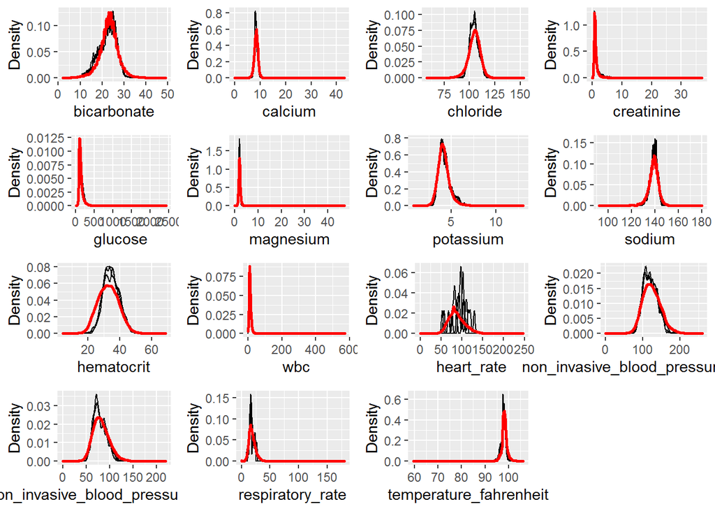

```r
plotDistributions(miceObj,vars='allNumeric')
```

The boxplots of the correlations between imputed values in every combination of datasets at each iteration show how values between datasets converged over the iterations. We didn’t see much convergence towards higher correlations among the variables, but this may be due to the max depth limitations placed on the MICE algorithm.

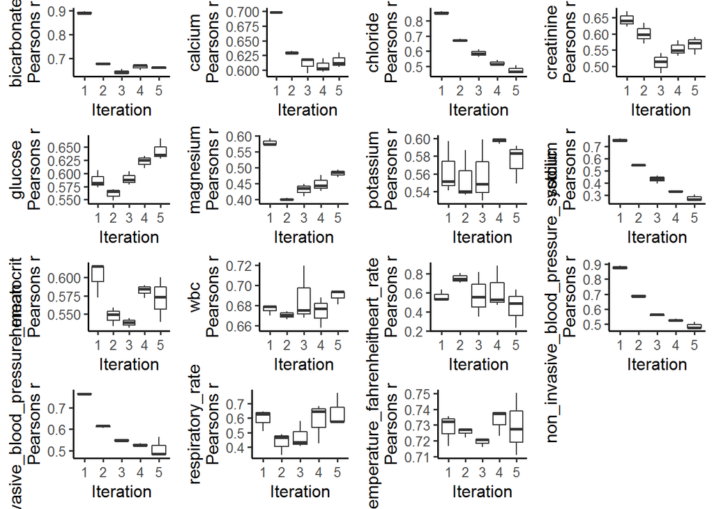

```r
plotCorrelations(miceObj,vars='allNumeric')
```

The trace plots show the center and dispersion convergence. It seems that most means and standard deviations converge towards similar values after 5 iterations for the three imputed datasets with the exception of heart rate, temperature fahrenheit, respiratory rate, non_invasive systolic blood pressure, and non-invasive mean blood pressure.

```r
#Center and Dispersion Convergence
colnames(icu_cohort_filtered)
```

```
##  [1] "subject_id"
##  [2] "gender"
##  [3] "age_at_adm"
##  [4] "marital_status"
##  [5] "bicarbonate"
##  [6] "calcium"
##  [7] "chloride"
##  [8] "creatinine"
##  [9] "glucose"
## [10] "magnesium"
## [11] "potassium"
## [12] "sodium"
## [13] "hematocrit"
## [14] "wbc"
## [15] "heart_rate"
## [16] "non_invasive_blood_pressure_systolic"
## [17] "non_invasive_blood_pressure_mean"
## [18] "respiratory_rate"
## [19] "temperature_fahrenheit"
## [20] "died_within_30_days"
```

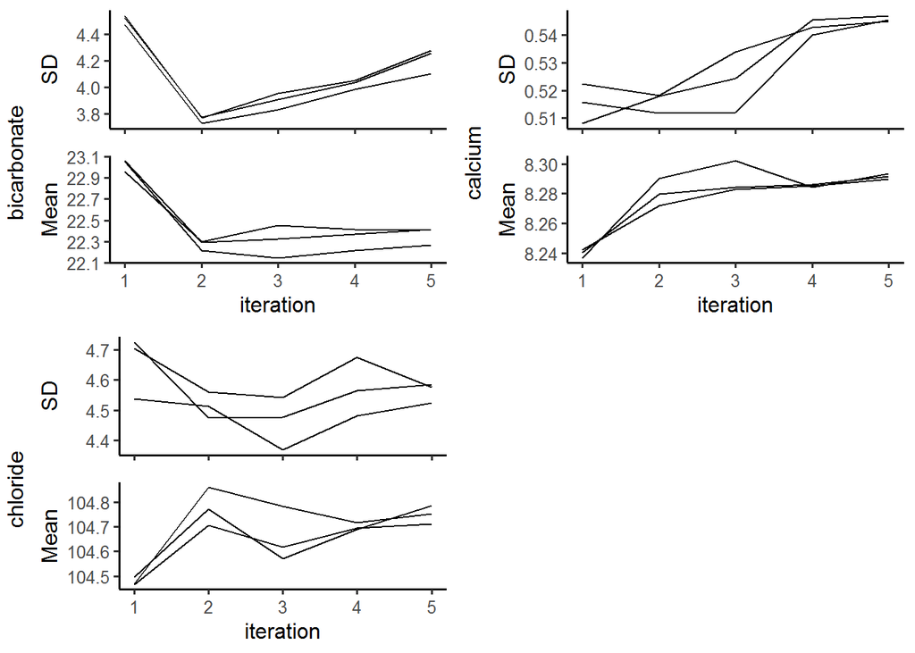

```r
plotVarConvergence(miceObj,vars=c("bicarbonate", "calcium",
                                  "chloride"))
```

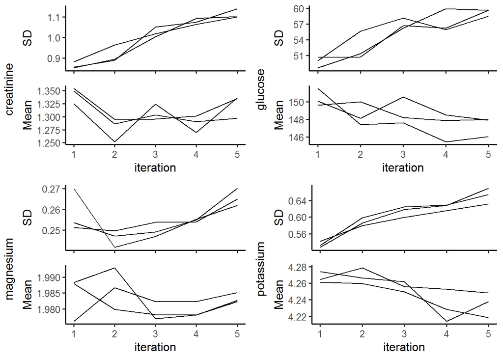

```r
plotVarConvergence(miceObj,vars=c("creatinine", "glucose",
                                  "magnesium", "potassium"))
```

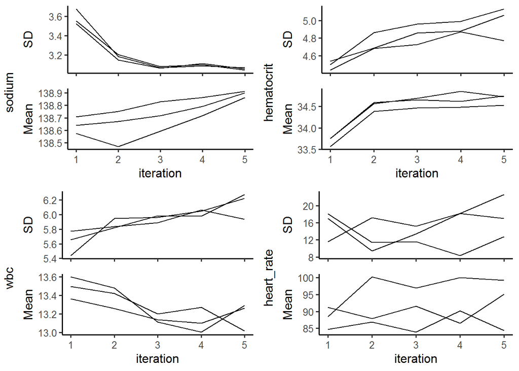

```r
plotVarConvergence(miceObj,vars=c("sodium", "hematocrit", "wbc",
                                  "heart_rate"))
```

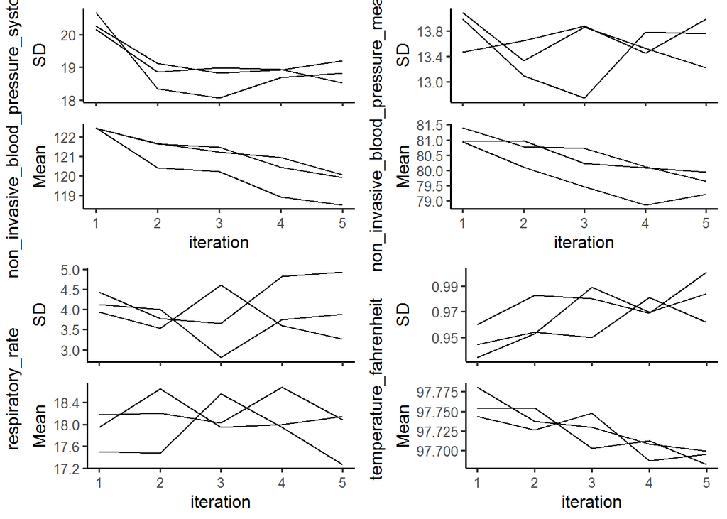

```r
plotVarConvergence(miceObj,vars=c("non_invasive_blood_pressure_systolic",
                                  "non_invasive_blood_pressure_mean",
                                  "respiratory_rate",
                                  "temperature_fahrenheit"))
```

### Part 6

6. Obtain a complete data set by averaging the 3 imputed data sets.

**Q1.6 Solution**

The function `quiet` is used to supress the output to speed up the dataframe combining process.

```r
#Obtain imputed datasets
quiet(imputedList <- completeData(miceObj))

#Convert categorical variables to numeric
quiet(imputedList$Dataset_1$marital_status <-
  unclass(imputedList$Dataset_1$marital_status))

quiet(imputedList$Dataset_2$marital_status <-
  unclass(imputedList$Dataset_2$marital_status))

quiet(imputedList$Dataset_3$marital_status <-
  unclass(imputedList$Dataset_3$marital_status))

quiet(imputedList$Dataset_1$gender <-
  as.numeric(imputedList$Dataset_1$gender))

quiet(imputedList$Dataset_2$gender <-
  as.numeric(imputedList$Dataset_2$gender))

quiet(imputedList$Dataset_3$gender <-
  as.numeric(imputedList$Dataset_3$gender))

quiet(imputedList$Dataset_1$died_within_30_days <-
  as.numeric(imputedList$Dataset_1$died_within_30_days))

quiet(imputedList$Dataset_2$died_within_30_days <-
  as.numeric(imputedList$Dataset_2$died_within_30_days))

quiet(imputedList$Dataset_3$died_within_30_days <-
  as.numeric(imputedList$Dataset_3$died_within_30_days))

#Average data sets
quiet(
  icu_cohort_filtered_imputed <-
    rbindlist(list(imputedList$Dataset_1,
                   imputedList$Dataset_2,
                   imputedList$Dataset_3))[,lapply(.SD,mean), list(subject_id)]
  )

#Factorize gender and 30 day mortality status again
icu_cohort_filtered_imputed$gender<-recode(icu_cohort_filtered_imputed$gender,
                                           `1` = 0, `2` = 1)
icu_cohort_filtered_imputed$gender <- factor(icu_cohort_filtered_imputed$gender)

#Factorize death within 30 days
icu_cohort_filtered_imputed$died_within_30_days<-recode(
  icu_cohort_filtered_imputed$died_within_30_days, `1` = 0, `2` = 1)

icu_cohort_filtered_imputed$died_within_30_days <- factor(
  icu_cohort_filtered_imputed$died_within_30_days)

#Remove subject_id variable now
icu_cohort_filtered_imputed <-
  subset(icu_cohort_filtered_imputed, select = -c(subject_id))
```

Remove unnecessary objects to clear environment memory.

```r
rm(miceObj,imputedList, icu_cohort_filtered)
```

## Q2. Predicting 30-day mortality

Develop at least two analytic approaches for predicting the 30-day mortality of patients admitted to ICU using demographic information (gender, age, marital status, ethnicity), first lab measurements during ICU stay, and first vital measurements during ICU stay. For example, you can use (1) logistic regression (`glm()` function), (2) logistic regression with lasso penalty (glmnet package), (3) random forest (randomForest package), or (4) neural network.

### Part 1

1. Partition data into 80% training set and 20% test set. Stratify partitioning according the 30-day mortality status.

**Q2.1 Solution**

First, let’s tabulate the 30-day mortality status variable to see the frequencies. About 90.2% did not died within 30 days of ICU admission and 9.8% died within 30 days of ICU admission.

```r
table(icu_cohort_filtered_imputed$died_within_30_days)/
  nrow(icu_cohort_filtered_imputed)
```

```
##
##          0          1
## 0.90231378 0.09768622
```

We will stratify the partioning according to these frequencies of 30-day mortality status. We will use `split_train_test` from the `healthcareai` package to accomplish this.

```r
partitioned_data<-split_train_test(d=icu_cohort_filtered_imputed,
                                   outcome=died_within_30_days,
                                   percent_train = 0.8, seed=1)
train <- partitioned_data$train
test <- partitioned_data$test
```

### Parts 2 & 3

2. Train the models using the training set.
3. Compare model prediction performance on the test set.

**Q2.2 and Q2.3 Solution**

#### Logistic regression with lasso penalty

We will use `glmnet()` to perform this analysis. First, we need to do some data preparation. We will use `model.matrix()` to create a matrix of predictors with categorical variables one-hot-encoded. Categorical variables need to be one-hot-encoded to work for `glmnet()`. Reference for my code can be found [here](http://www.sthda.com/english/articles/36-classification-methods-essentials/149-penalized-logistic-regression-essentials-in-r-ridge-lasso-and-elastic-net/)

```r
#Dummy code categorical predictor variables
x<-model.matrix(died_within_30_days~., train)[,-1]

#Assign outcome to y
y<-train$died_within_30_days
```

Now we can computed the penalized logistic regression. First, we’ll find the best lambda value to minimuze the cross_validation error. The lambda that minimizes the prediction error is $\lambda_{min}$ = 0.0002962146. However, [literature](https://stats.stackexchange.com/questions/138569/why-is-lambda-within-one-standard-error-from-the-minimum-is-a-recommended-valu) sugggests using the lambda within one standard error from the minimum becuase it gives the simplest model. The calculated lambda within one standard error is $\lambda_{1se}$ = 0.004827559

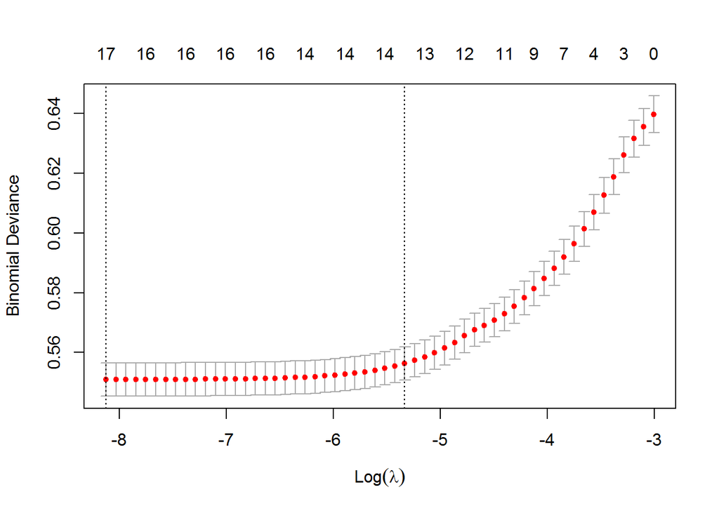

```r
set.seed(1)
cv.lasso <- cv.glmnet(x, y, alpha=1, family = "binomial")
plot(cv.lasso)
```

```r
cv.lasso$lambda.min
```

```
## [1] 0.0002962146
```

```r
cv.lasso$lambda.1se
```

```
## [1] 0.004827559
```

**Lambda that minimizes prediction error**

Let’s try using the lambda value that minimizes the prediction error first.

```r
#Fit model on training data
model_min <- glmnet(x, y, family= "binomial",
                    alpha=1, lambda=cv.lasso$lambda.min)
```

Now we can make predictions on the test data.

```r
x.test<-model.matrix(died_within_30_days~., test)[,-1]
probabilities_min <- model_min %>% predict (newx = x.test)
predicted.classes_min <- ifelse(probabilities_min > 0.5, 1, 0)
```

Let’s assess model accurracy.

```r
observed.classes <- test$died_within_30_days
mean(predicted.classes_min == observed.classes)
```

```
## [1] 0.9047762
```

Using $\lambda_{min}$ gives an accuracy of 90.5%.

**Lambda that is one standard error from the minimum**

```r
#Fit model on training data
model_1se <- glmnet(x, y, family= "binomial",
                    alpha=1, lambda=cv.lasso$lambda.1se)
```

Now we can make predictions on the test data.

```r
probabilities_1se <- model_1se %>% predict (newx = x.test)
predicted.classes_1se <- ifelse(probabilities_1se > 0.5, 1, 0)
```

Let’s assess model accurracy.

```r
mean(predicted.classes_1se == observed.classes)
```

```
## [1] 0.9034772
```

Using $\lambda_{1se}$ gives an accuracy of 90.3%.

```r
#Using the lambda that minimizes prediction error
coef(model_min)
```

```
## 19 x 1 sparse Matrix of class "dgCMatrix"
##                                                 s0
## (Intercept)                           7.5940622769
## gender1                               .
## age_at_adm                            0.0312784207
## marital_status                        0.0141930267
## bicarbonate                          -0.1240091804
## calcium                              -0.1539996497
## chloride                             -0.1040272697
## creatinine                            0.0169965417
## glucose                               0.0012494104
## magnesium                             0.0933300535
## potassium                             0.1614611458
## sodium                                0.1019748898
## hematocrit                            0.0020812460
## wbc                                   0.0145249557
## heart_rate                            0.0103237614
## non_invasive_blood_pressure_systolic -0.0071787936
## non_invasive_blood_pressure_mean      0.0002083488
## respiratory_rate                      0.0344044760
## temperature_fahrenheit               -0.1355803913
```

```r
#Using the lambda that is 1 SE from the minimum
coef(model_1se)
```

```
## 19 x 1 sparse Matrix of class "dgCMatrix"
##                                                s0
## (Intercept)                           5.754090476
## gender1                               .
## age_at_adm                            0.026534651
## marital_status                        .
## bicarbonate                          -0.101863603
## calcium                              -0.029864226
## chloride                             -0.054707877
## creatinine                            0.042708495
## glucose                               0.001210180
## magnesium                             .
## potassium                             0.089910260
## sodium                                0.045110281
## hematocrit                            .
## wbc                                   0.012510143
## heart_rate                            0.008567231
## non_invasive_blood_pressure_systolic -0.004950545
## non_invasive_blood_pressure_mean      .
## respiratory_rate                      0.032634090
## temperature_fahrenheit               -0.095440186
```

#### Random forest

Let’s attempt to use random forests to classify patients to a 30-day mortality status.

```r
# Clear memory first

#Garbage collection to clear memory
gc()
```

```
##              used    (Mb) gc trigger    (Mb)   max used    (Mb)
## Ncells   16228453   866.7   23327282  1245.9   16856295   900.3
## Vcells 1678511739 12806.1 2344646230 17888.3 1718905804 13114.3
```

```r
#Remove all objects that are not needed
quiet(rm(list=setdiff(ls(), c("working_path", "icu_cohort_filtered_imputed",
                              "test", "train"))))
```

After the model is evaluated on the testing data set, we can see that we have a 90.9% accuracy! This is pretty good and only slightly better than the logistic regression with lasso penalty algorithm.

```r
#Evaluate the model
prediction <-predict(mortalitystatus_train, test)
confusionMatrix(prediction, test$died_within_30_days)
```

```
## Confusion Matrix and Statistics
##
##           Reference
## Prediction    0    1
##          0 8989  868
##          1   42  109
##
##                Accuracy : 0.9091
##                  95% CI : (0.9033, 0.9146)
##     No Information Rate : 0.9024
##     P-Value [Acc > NIR] : 0.01196
##
##                   Kappa : 0.1716
##
##  Mcnemar's Test P-Value : < 2e-16
##
##             Sensitivity : 0.9953
##             Specificity : 0.1116
##          Pos Pred Value : 0.9119
##          Neg Pred Value : 0.7219
##              Prevalence : 0.9024
##          Detection Rate : 0.8982
##    Detection Prevalence : 0.9849
##       Balanced Accuracy : 0.5535
##
##        'Positive' Class : 0
##
```

We can see the variable importance as follows. The variable importance seems to suggest that the model may better predict 30-day mortality status where we see negative variable importance.

```r
randomForest::importance(mortalitystatus_train)
```

```
##                                             0          1 MeanDecreaseAccuracy
## gender                               13.73247 -0.7271893             12.58162
## age_at_adm                           50.42353 33.7016846             58.78569
## marital_status                       20.42184 -0.2385714             19.35283
## bicarbonate                          32.47550 48.0428322             52.15393
## calcium                              36.51769  8.7185996             38.12735
## chloride                             54.66737 -1.1186699             55.34040
## creatinine                           20.82913 44.4436979             38.66232
## glucose                              18.50109 36.5362304             31.60436
## magnesium                            20.91521 16.1471269             26.61976
## potassium                            18.30750 16.8098438             24.48441
## sodium                               47.81351  3.0301290             49.49809
## hematocrit                           29.68174  7.4501478             30.24996
## wbc                                  16.59296 48.2365574             35.90184
## heart_rate                           34.14719  9.2458087             35.62457
## non_invasive_blood_pressure_systolic 45.28587 12.6757653             49.21341
## non_invasive_blood_pressure_mean     48.27464  0.2957983             49.18858
## respiratory_rate                     25.45156 17.1470128             30.01380
## temperature_fahrenheit               28.28648 47.2559528             47.01255
##                                      MeanDecreaseGini
## gender                                       40.81701
## age_at_adm                                  437.35117
## marital_status                              147.77921
## bicarbonate                                 503.96865
## calcium                                     395.23312
## chloride                                    340.66455
## creatinine                                  491.81226
## glucose                                     500.06436
## magnesium                                   309.06195
## potassium                                   372.36343
## sodium                                      355.95385
## hematocrit                                  443.46146
## wbc                                         577.58426
## heart_rate                                  428.88642
## non_invasive_blood_pressure_systolic        441.42217
## non_invasive_blood_pressure_mean            405.75954
## respiratory_rate                            355.07897
## temperature_fahrenheit                      518.92250
```

In conclusion, either logistic regression with lasso penalty or random forests can be used to predict the 30-day mortality status of the patients in the ICU cohort with 90%+ accuracy.